# Projeto de Medição - ADSD

Gileade, Rafael, Samantha

## Introdução

### Objetivo

O sistema real que utilizaremos para realizar o projeto de medição será uma Cloud [OpenStack](https://www.openstack.org/) que monitora duas máquinas físicas (hosts). Estas máquinas serão de uso exclusivo da equipe durante o experimento. Nosso objetivo é testar diferentes políticas de alocação de máquinas virtuais nos hosts (Consolidação ou Espalhamento) e pontuar aspectos positivos e negativos de ambas estratégias. As máquinas virtuais selecionadas para serem alocadas no sistema terão um workload IO-Bound sintético atrelada a elas.

### Fatores

- Política de alocação: Consolidação ou Espalhamento.
- Tamanho do workload: Large ou Small.
- Tamanho das máquinas virtuais: Large ou Small.

### Métricas

- Energia consumida pelas máquinas físicas.
- Temperatura dos sensores das máquinas físicas.
- Tempo de execução dos workloads.

O experimento foi realizado adotando o design fatorial completo. Como existem 3 fatores com 2 níveis cada um, teremos 2^3 (8) tratamentos em cada replicação. Adotamos o número de 30 replicações a fim de obter maior precisão estatística.

## Tratamento dos dados

```r
library(tidyverse)
library(here)
theme_set(theme_bw())
options(scipen = 999)
```

```r
## Leitura de todos os csvs referentes a medicao

files <- list.files(path = here("data"), pattern = "*.csv")

medicao_full <- files %>%
    map(function(x) {
        read_csv(paste0(here("data/"), x))
    }) %>%
  reduce(rbind)
```

Nos dados da medição, temos informações da temperatura da vm e da energia consumida a cada segundo. Agrupamos essas medições pelo número da repetição, política de alocação, tamanho do workload, tamanho da vm. Em seguida sumarizamos definindo o tempo de workload como a diferença entre o maior e o menor tempo, ou seja, o tempo gasto para o workload ser processado. Também definimos a mediana como medida de tendência central, por ser mais robusta e sofrer menos influência de valores extremos. Usamos a mediana para definir a medida central que representa a energia consumida (W) e a temperatura (celsius) para um determinado tratamento.

```r
medicao_summ <- medicao_full %>%
  arrange(rep_id) %>%
  select(rep_id, placement_policy, workload_size, vm_size, time, host_power, host_temperature) %>%
  group_by(rep_id, placement_policy, workload_size, vm_size) %>%
  summarise(workload_time = max(time) - min(time),
         host_power = median(host_power),
         host_temperature = median(host_temperature)) %>%
  ungroup()

medicao_summ$vm_size = ordered(medicao_summ$vm_size, levels = c("small", "large"))
```

Portanto, cada observação deste dataframe corresponde a uma determinada repetição (rep_id) para um determinado tratamento, definido por uma política de alocação (placement_policy), tamanho do workload (workload_size) e tamanho da vm (vm_size), um tempo (medido em segundos), consumo de energia (mediana do consumo de energia durante o tempo de execução do workload), temperatura do host (mediana da temperatura do host durante o tempo de execução do workload).

## Análise sobre os dados

Inicialmente vamos entender o comportamento dos dados buscando relacionar a variação dos fatores com cada métrica calculada. Para atender este objetivo a visualização a seguir mostra por política de alocação (cada quadro), tamanho do workload (eixo x) e tamanho da VM (cor) qual o tempo de execução do workload. É possível visualizar as observações para cada tratamento e repetição, e também um boxblot para sumarização destes grupos.

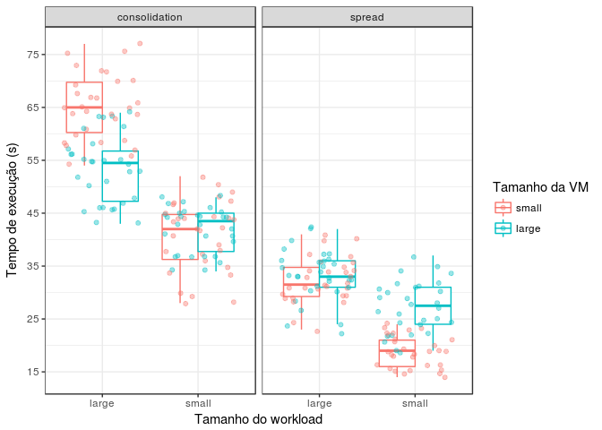

```r
medicao_summ %>%
  ggplot(aes(x = workload_size, y = workload_time, color = vm_size)) +
  geom_boxplot(outlier.shape = "") +
  geom_jitter(alpha = .4) +
  facet_grid(. ~ placement_policy) +
  scale_y_continuous(breaks = seq(5, 80, 10)) +
  labs(x = "Tamanho do workload", y = "Tempo de execução (s)", color = "Tamanho da VM")
```

Agora que sabemos que tipo de visualização estamos lidando, podemos aprofundar a interpretação.

Pela visualização é possível observar que, com relação ao tempo de execução, a política de alocação **Consolidation** possui valores mais altos do que a política de alocação **spread**.

Quando a política de alocação é consolidação e tamanho do workload é large, podemos observar uma diferença com relação ao tempo entre o tamanho da VM. Quando a vm tem o tamanho small, o tempo de execução é maior do que quando a vm tem o tamanho large. O que faz sentido, uma vez que uma VM do tamanho large tem maior poder computacional do que uma do tamanho small.

Quando o tratamento observado é o que indica a política de alocação como sendo consolidação e o tamanho do workload como small, há uma pequena diferença entre o tempo de execução. De forma análoga, observamos quando a política de alocação é spread e o tamanho do workload é large, a diferença entre as médias é pequena. Os pontos (observações) parecem estar bem próximos

Quando paramos para comparar o tamanho do workload, as diferenças do tempo entre large e small se mostram evidentes. O que faz sentido, uma vez que um workload menor tende a rodar em menos tempo.

De forma análoga, podemos visualizar o comportamento dos dados, durante a variação dos fatores, focando na métrica de temperatura dos hosts (mediana da temperatura considerando o intervalo de tempo de execução do workload).

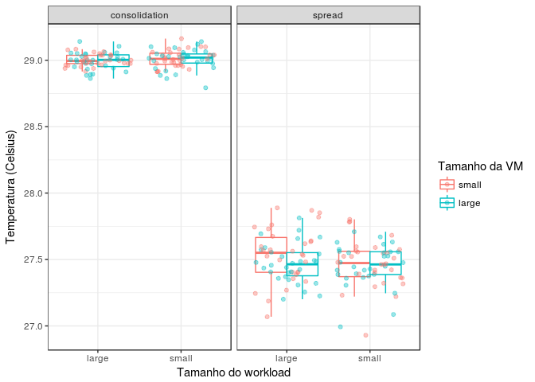

```r
medicao_summ %>%
  ggplot(aes(x = workload_size, y = host_temperature, color = vm_size)) +
  geom_boxplot(outlier.shape = "") +
  geom_jitter(alpha = .4) +
  facet_grid(. ~ placement_policy) +
  labs(x = "Tamanho do workload", y = "Temperatura (Celsius)", color = "Tamanho da VM")
```

Por esta visualização perecebemos uma diferença com relação a temperatura entre as políticas de alocação. A política de alocação possui maiores registros de temperatura do que a política spread.

Quando a política de alocação é consolidation existe pouca diferença entre a temperatura durante a variação dos fatores de tamanho do workload e tamanho da VM.

Quando a política de alocação é spread e o tamanho do workload é large, percebemos uma pequena diferença entre o tamanho da VM. VMs de tamanho small possuem uma média de temperatura durante a execução do workload maior que as de tamanho large.

Por último, a visualização do comportamento com relação a métrica consumo de energia (mediana do consumo de energia considerando o intevalo de tempo de execução do workload para o determinado tratamento e repetição).

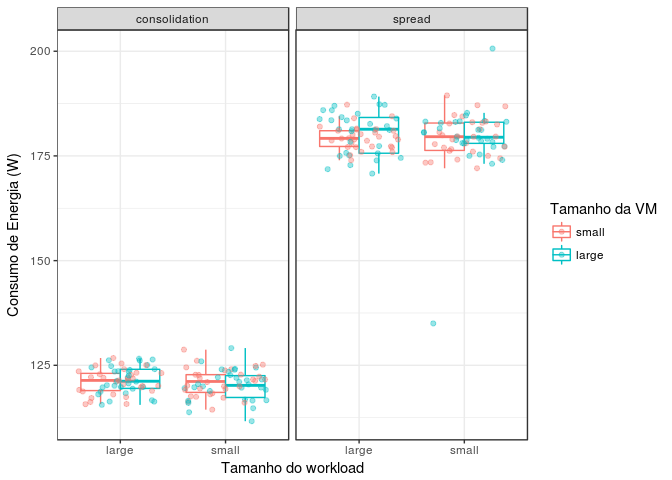

```r
medicao_summ %>%
  ggplot(aes(x = workload_size, y = host_power, color = vm_size)) +
  geom_boxplot(outlier.shape = "") +
  geom_jitter(alpha = .4) +
  facet_grid(. ~ placement_policy) +
  labs(x = "Tamanho do workload", y = "Consumo de Energia (W)", color = "Tamanho da VM")
```

É visível a diferença entre o consumo de energia com relação a política de alocação. Spread consome bem mais energia do que consolidation. Os demais fatores, tamanho da vm e tamanho do workload parecem influenciar bem menos o consumo de energia, apresentando poucas diferenças quando variamos seus níveis. Interessante também notar a presença de alguns outliers (perto do consumo 200 e perto do consumo 137) quando o tratamento foi spread, tamanho do workload small e tamanho da vm large. Para os outros tratamentos e em outras repetições não observamos muitos outliers com relação ao consumo de energia (considerando a diferença dentro do tratamento específico).

### Intervalo de confiança

O objetivo nesta seção é determinar o intervalo de confiança para cada métrica observada, quando comparamos cada nível dos 3 fatores. Por exemplo, qual o intevalo de confiança para o tempo de execução quando o nível para a política de alocação é Consolidação? E quando o nível é Espalhamento?

#### Tempo de execução

##### Política de alocação

```r
consolidation <- t.test((medicao_summ %>% filter(placement_policy == "consolidation"))$workload_time)$conf.int
consolidation
```

```
## Time differences in secs
## [1] 48.22911 52.40422
## attr(,"conf.level")
## [1] 0.95
```

```r
espalhamento <- t.test((medicao_summ %>% filter(placement_policy == "spread"))$workload_time)$conf.int
espalhamento
```

```
## Time differences in secs
## [1] 26.58701 29.17965
## attr(,"conf.level")
## [1] 0.95
```

Com o nível de confiança de 95%, determinamos o intervalo de confiança para o valor do tempo de execução para cada nível do fator **política de alocação**. E como apontado pelos valores acima, a política spread apresenta um intervalo de confiança posicionado abaixo do intervalo da política consolitation. Como os intervalos não possuem intersecção, podemos afirmar com 95% de confiança que **a variação do fator política de alocação altera o tempo de execução dos workloads** submetidos no experimento.

##### Tamanho da VM

```r
large <- t.test((medicao_summ %>% filter(vm_size == "large"))$workload_time)$conf.int
large
```

```
## Time differences in secs
## [1] 36.94676 40.95324
## attr(,"conf.level")
## [1] 0.95
```

```r
small <- t.test((medicao_summ %>% filter(vm_size == "small"))$workload_time)$conf.int
small
```

```
## Time differences in secs
## [1] 36.03839 42.46161
## attr(,"conf.level")
## [1] 0.95
```

Quando variamos o tamanho da VM, perecebemos que os intervalos para cada nível do fator (small ou large) são bem parecidos. O que nos leva a afirmar, com 95% de confiança, que isoladamente o fator tamanho da VM não influencia no tempo de execução dos workloads.

##### Tamanho do workload

```r
large <- t.test((medicao_summ %>% filter(workload_size == "large"))$workload_time)$conf.int
large
```

```
## Time differences in secs
## [1] 43.30667 48.72666
## attr(,"conf.level")
## [1] 0.95
```

```r
small <- t.test((medicao_summ %>% filter(workload_size == "small"))$workload_time)$conf.int
small
```

```
## Time differences in secs
## [1] 30.22569 34.14098
## attr(,"conf.level")
## [1] 0.95
```

Como mostrado a seguir, os intervalos de confiança, com 95% de confiança quando variamos os níveis para o fator tamanho do workload apontam que os workloads com tamanho small possuem um menor tempo de execução que os workloads de tamanho large.

#### Consumo de energia

##### Política de alocação

```r
consolidation <- t.test((medicao_summ %>% filter(placement_policy == "consolidation"))$host_power)$conf.int
consolidation
```

```
## [1] 120.3253 121.5309
## attr(,"conf.level")
## [1] 0.95
```

```r
espalhamento <- t.test((medicao_summ %>% filter(placement_policy == "spread"))$host_power)$conf.int
espalhamento
```

```
## [1] 178.5705 180.7523
## attr(,"conf.level")
## [1] 0.95
```

Com relação ao consumo de energia, é possível afirmar que, com 95% de confiança, o intervalo de confiança que contém o valor do consumo de energia quando a política de alocação é spread é superior ao da política de alocação consolidation.

##### Tamanho da VM

```r
large <- t.test((medicao_summ %>% filter(vm_size == "large"))$host_power)$conf.int
large
```

```
## [1] 144.8777 155.7955
## attr(,"conf.level")
## [1] 0.95
```

```r
small <- t.test((medicao_summ %>% filter(vm_size == "small"))$host_power)$conf.int
small
```

```
## [1] 144.9066 155.5991
## attr(,"conf.level")
## [1] 0.95
```

Com relação a variação dos níveis para o fator tamanho da vm, os intervalos de confiança foram bastante parecidos. O que indica que isoladamente este fator não influencia no consumo de energia.

##### Tamanho do workload

```r
large <- t.test((medicao_summ %>% filter(workload_size == "large"))$host_power)$conf.int
large
```

```
## [1] 145.2707 156.0162
## attr(,"conf.level")
## [1] 0.95
```

```r
small <- t.test((medicao_summ %>% filter(workload_size == "small"))$host_power)$conf.int
small
```

```
## [1] 144.5139 155.3781
## attr(,"conf.level")
## [1] 0.95
```

Os intervalos de confiança são parecidos, o que leva a afirmar, com 95% de confiança, que a variação do fator tamanho do workload isoladamente não causou diferença no consumo de energia.

#### Temperatura nos Hosts

##### Política de alocação

```r
consolidation <- t.test((medicao_summ %>% filter(placement_policy == "consolidation"))$host_temperature)$conf.int
consolidation
```

```
## [1] 28.9919 29.0148
## attr(,"conf.level")
## [1] 0.95
```

```r
espalhamento <- t.test((medicao_summ %>% filter(placement_policy == "spread"))$host_temperature)$conf.int
espalhamento
```

```
## [1] 27.45216 27.51579
## attr(,"conf.level")
## [1] 0.95
```

Os valores dos intervalos de confiança para cada nível do fator política de alocação indicam que, com 95% de confiança, a temperatura dos hosts para consolidação é maior que a temperatura quando a política é spread.

##### Tamanho da VM

```r
large <- t.test((medicao_summ %>% filter(vm_size == "large"))$host_temperature)$conf.int
large
```

```
## [1] 28.09014 28.37230
## attr(,"conf.level")
## [1] 0.95
```

```r
small <- t.test((medicao_summ %>% filter(vm_size == "small"))$host_temperature)$conf.int
small
```

```
## [1] 28.11733 28.39489
## attr(,"conf.level")
## [1] 0.95
```

O intervalo de confiança, gerado com nível de confiança de 95%, indica que a variação fator tamanho da vm, isoladamente, pouco influencia na temperatura dos hosts.

##### Tamanho do workload

```r
large <- t.test((medicao_summ %>% filter(workload_size == "large"))$host_temperature)$conf.int
large
```

```
## [1] 28.11323 28.38846
## attr(,"conf.level")
## [1] 0.95
```

```r
small <- t.test((medicao_summ %>% filter(workload_size == "small"))$host_temperature)$conf.int
small
```

```
## [1] 28.09424 28.37872
## attr(,"conf.level")
## [1] 0.95
```

O intervalo de confiança, gerado com nível de confiança de 95%, indica que a variação do tamanho do workload, isoladamente, pouco influencia na temperatura dos hosts.

## Conclusão

Quando analisamos de forma isolada cada fator percemos que: * O tamanho do workload e da VM pouco influenciam de forma isolada e individual as métricas utilizadas. Com exceção do fator tamanho do workload que influencia na métrica tempo de execução. * O fator que apresenta maior influência para as métricas utilizadas é o da política de alocação. Com relação ao tempo de execução, a política spread se mostrou mais eficiente (menor tempo) que a política consolidation. Já em relação ao consumo de energia, a política spread apresentou maiores valores que a consolidation. E por último, a política consolidation apresentou maiores valores de temperatura nos hosts quando comparada a política spread.

### Outras visualizações

Foi interessante notar na seção anterior como os fatores podem influenciar de forma isolada as métricas que utilizamos. Mas será que existem influência quando os fatores são combinados também? Esta pergunta já começou a ser respondida durante as interpretações para as visualizações de exploração dos dados. No entanto vamos reforçá-la usando novas visualizações.

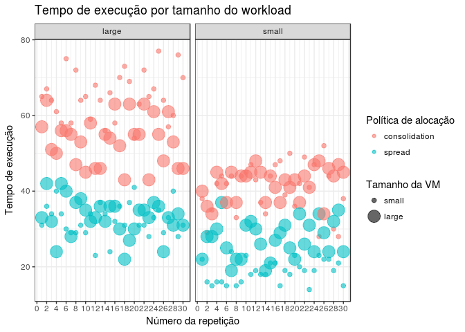

```r
medicao_summ %>%
  ggplot(aes(x = rep_id, y = workload_time, color = placement_policy, size = vm_size)) +
  geom_point(alpha = 0.6) +
  scale_x_continuous(breaks = seq(0, 32, 2)) +
  facet_grid(. ~ workload_size) +
  labs(x = "Número da repetição", y = "Tempo de execução", color = "Política de alocação", size = "Tamanho da VM", title = "Tempo de execução por tamanho do workload")
```

Nesta visualização temos ordenadas todas as observações medidas para as 30 repetições do experimento realizadas. Esta visualização contém 240 pontos que correspondem aos 8 tratamentos replicados 30 vezes. O número 8 vem do design do experimento que é fatorial completo com 3 fatores de dois níveis cada. O tamanho dos pontos varia conforme os níveis do fator tamanho da VM e a cor conforme a política de alocação. Ainda é possível observar que os gráficos estaão dividos em duas facetas, uma para o tamanho de workload large e outra para o tamanho small.

Com relação ao tempo de execução podemos novamente afirmar, olhando a distribuição dos pontos que a política consolidação (em goiaba) apresenta maiores valores do que a spread (em azul-esverdeado). Quando olhamos para o tamanho da vm, observamos que quando o workload é small e a política de alocação é spread, há uma diferença entre os valores, de forma que o tamanho da VM large apresenta maiores tempos de execução que o tamanho small.

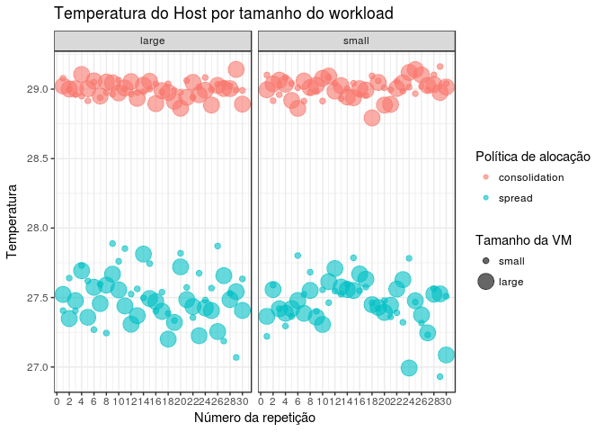

```r
medicao_summ %>%
  ggplot(aes(x = rep_id, y = host_temperature, color = placement_policy, size = vm_size)) +
  geom_point(alpha = 0.6) +
  facet_grid(. ~ workload_size) +
  scale_x_continuous(breaks = seq(0, 32, 2)) +
  labs(x = "Número da repetição", y = "Temperatura", color = "Política de alocação", size = "Tamanho da VM", title = "Temperatura do Host por tamanho do workload")
```

Por esta visualização é possível observar a diferença de temperatura quando variamos o nível do fator política de alocação. Consolidation apresenta valores maiores que spread.

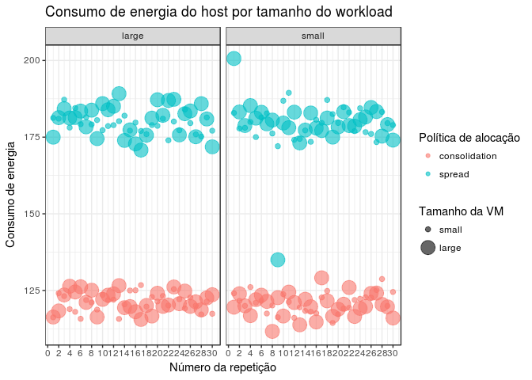

```r
medicao_summ %>%
  ggplot(aes(x = rep_id, y = host_power, color = placement_policy, size = vm_size)) +
  geom_point(alpha = 0.6) +
  facet_grid(. ~ workload_size) +
  scale_x_continuous(breaks = seq(0, 32, 2)) +
  labs(x = "Número da repetição", y = "Consumo de energia", color = "Política de alocação", size = "Tamanho da VM", title = "Consumo de energia do host por tamanho do workload")
```

Por esta visualização é novamente notável a diferença de consumo de energia entre as políticas de alocação. Consolidation apresenta um menor consumo do que spread. Os demais fatores parecem influenciar pouco.